# Clustering Lab

Anna Ramji

2024-02-29

```
##
##
## • Learn how to get started at https://www.tidymodels.org/start/
```

We’ll start off with some simulated data that has a structure that is amenable to clustering analysis.

```r
# Set the parameters of our simulated data
set.seed(101)

# setting parameters
# centers
cents <- tibble(
  cluster = factor(1:3), # 3 clusters, labelled 1, 2, 3
  num_points = c(100, 150, 50), # 3 sizes of our diff clusters
  # anonymous simulated data
  # center of each cluster = (x1, x2)
  x1 = c(5, 0, -3),
  x2 = c(-1, 1, -2)

)
```

“how do we set this up so that when we simulate the data, it conforms to these certain characteristics”

map2: These functions are variants of map() that iterate over two arguments at a time

```r
# Simulate the data by passing n and mean to rnorm using map2()

labelled_pts <-
  cents |>
  mutate(
    # applies rnorm function to specified number of points, coordinate x1
    x1 = map2(num_points, x1, rnorm),
    x2 = map2(num_points, x2, rnorm)

  ) |>
  select(-num_points) |>
  unnest(cols = c(x1, x2))

labelled_pts
```

```
## # A tibble: 300 × 3
##    cluster    x1      x2
##    <fct>   <dbl>   <dbl>
##  1 1        4.67 -2.17
##  2 1        5.55 -1.24
##  3 1        4.33  0.184
##  4 1        5.21 -0.792
##  5 1        5.31 -1.04
##  6 1        6.17 -1.97
##  7 1        5.62 -0.426
##  8 1        4.89 -2.26
##  9 1        5.92  0.0617
## 10 1        4.78 -1.43
## # ℹ 290 more rows
```

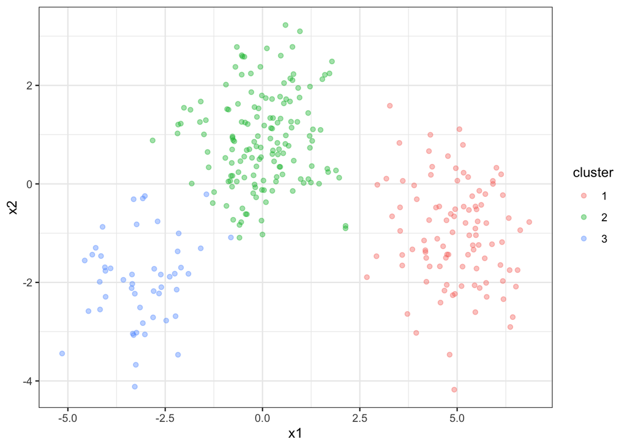

```r
ggplot(data = labelled_pts,
       aes(x1, x2, color = cluster)) +
  geom_point(alpha = 0.4) +
  theme_bw()
```

saying x2 instead of y because no outcome variable, just grouping identity

```r
# detect that there are 3 coherent groups here
points <-
  # observations
  labelled_pts |>
  # remove cluster (because that's the answer)
  select(-cluster)


kclust <- kmeans(points,
                 centers = 3, # start off by saying "I think there are 3 clusters"
                 n = 25 # running the same model n times, but with diff randomly selected starting points for the centroids (starts by randomly picking centroids, all points closest to that point are assigned, then calculate what the actual cluster center is -- depending on where it's placed)
                 # 25 times = reduces outcome sensitivity to those initial conditions
#                 nstart = # "if centers is a number, how many random sets should be chosen?"
                 )

kclust
```

```
## K-means clustering with 3 clusters of sizes 48, 100, 152
##
## Cluster means:
##             x1         x2
## 1 -3.194015379 -2.0272690
## 2  4.962808900 -1.0254665
## 3 -0.004476705  0.8627456
##
## Clustering vector:
##   [1] 2 2 2 2 2 2 2 2 2 2 2 2 2 2 2 2 2 2 2 2 2 2 2 2 2 2 2 2 2 2 2 2 2 2 2 2 2
##  [38] 2 2 2 2 2 2 2 2 2 2 2 2 2 2 2 2 2 2 2 2 2 2 2 2 2 2 2 2 2 2 2 2 2 2 2 2 2
##  [75] 2 2 2 2 2 2 2 2 2 2 2 2 2 2 2 2 2 2 2 2 2 2 2 2 2 2 3 3 3 3 3 3 3 3 3 3 3
## [112] 3 3 3 3 3 3 3 3 3 3 3 3 3 3 3 3 3 3 3 3 3 3 3 3 3 3 3 3 3 3 3 3 3 3 3 3 3
## [149] 3 3 3 3 3 3 3 3 3 3 3 3 3 3 3 3 3 3 3 3 3 3 3 3 3 3 3 3 3 3 3 3 3 3 3 3 3
## [186] 3 3 3 3 3 3 3 3 3 3 3 3 3 3 3 3 3 3 3 3 3 3 3 3 3 3 3 3 3 3 3 3 3 3 3 3 3
## [223] 3 3 3 3 3 3 3 3 3 3 3 3 3 3 3 3 3 3 3 3 3 3 3 3 3 3 3 3 1 1 1 1 1 1 1 1 1
## [260] 1 1 1 3 1 3 1 1 1 1 1 1 1 1 1 1 1 1 1 1 1 1 1 1 1 1 1 1 1 1 1 1 1 1 1 1 1
## [297] 1 1 1 1
##
## Within cluster sum of squares by cluster:
## [1]  66.89755 195.90406 277.61532
##  (between_SS / total_SS =  84.6 %)
##
## Available components:
##
## [1] "cluster"      "centers"      "totss"        "withinss"     "tot.withinss"
## [6] "betweenss"    "size"         "iter"         "ifault"
```

within cluster Sum of Squares – how tightly / dense these clusters are

total within each cluster, global

created some simulated data that would have 3 clusters, ran the model and told it we had 3 clusters, it told us what it thought those were, how well defined they were, how separated they were

now: tuning – parameter of k that corresponds to the (optimal) number of clusters the model should be looking for

```r
# now let's try a systematic method for setting k
# running multiple models, so plural
kclusts <-
  tibble(
    k = 1:9 # k is 1-9
  ) |>
  mutate(
    # for each one (k), run a model
    kclust = map(k,
                 # ~ means anonymous function
                 ~ kmeans(points, # data that we'll run kmeans on, with single list of k values
                             .x) # placeholder where k will be passed to
                 ),
    augmented = map(kclust,
                    augment,
                    points)

  ) # produces a list
```

for each value of k (1:9), ran kmeans model, clustering, tibble gives information for each point

```r
# append cluster assignment to tibble
# which cluster is each point associated with
assignments <-
  kclusts |>
  unnest(cols = c(augmented))

assignments
```

```
## # A tibble: 2,700 × 5
##        k kclust      x1      x2 .cluster
##    <int> <list>   <dbl>   <dbl> <fct>
##  1     1 <kmeans>  4.67 -2.17   1
##  2     1 <kmeans>  5.55 -1.24   1
##  3     1 <kmeans>  4.33  0.184  1
##  4     1 <kmeans>  5.21 -0.792  1
##  5     1 <kmeans>  5.31 -1.04   1
##  6     1 <kmeans>  6.17 -1.97   1
##  7     1 <kmeans>  5.62 -0.426  1
##  8     1 <kmeans>  4.89 -2.26   1
##  9     1 <kmeans>  5.92  0.0617 1
## 10     1 <kmeans>  4.78 -1.43   1
## # ℹ 2,690 more rows
```

```r
# adds cluster assignment to coordinates
# each row is a point, each point has an associated cluster assignment
```

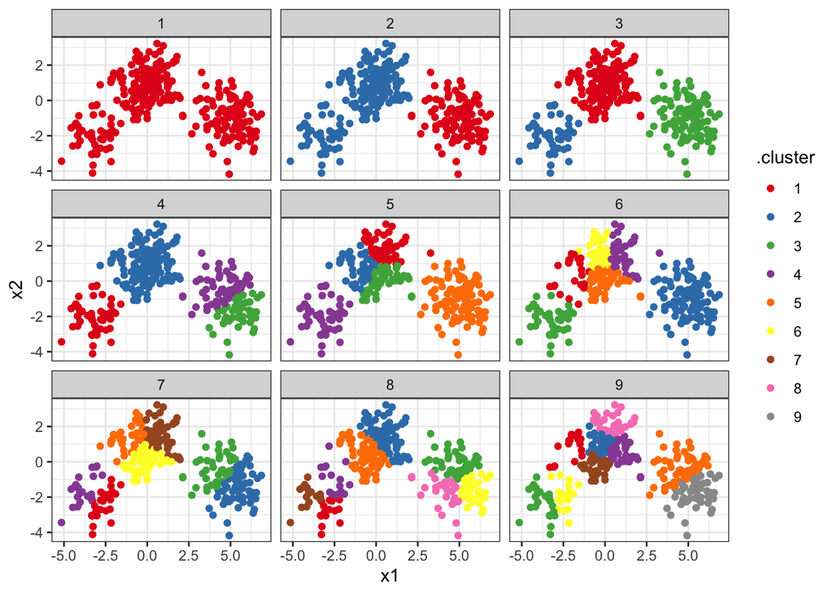

```r
# Plot each model

ggplot(data = assignments,
       aes(x = x1,
           y = x2)) +
  geom_point(aes(color = .cluster)) +
  theme_bw() +
  scale_color_brewer(palette = "Set1") +
  facet_wrap(~k)
```

k indicates the number of clusters that the model is assuming